# Part I: Exploratory Data Analysis

## Introduction

This notebook explores the Ford GoBike System Data for February 2019. We will systematically explore the dataset, starting from univariate analysis and building up to multivariate relationships. Key questions and observations will be documented throughout using the "Question-Visualization-Observations" framework.

```python
# Import required libraries
import numpy as np
import pandas as pd
import matplotlib.pyplot as plt
import seaborn as sns

%matplotlib inline
```

## Preliminary Wrangling

Load the dataset and perform initial cleaning and inspection.

```python
# Load the dataset
df = pd.read_csv('201902-fordgobike-tripdata.csv')
df.head()
```

|  | duration_sec | start_time | end_time | start_station_id | start_station_name | start_station_latitude | start_station_longitude | end_station_id | end_station_name | end_station_latitude | end_station_longitude | bike_id | user_type | member_birth_year | member_gender | bike_share_for_all_trip |
| --- | --- | --- | --- | --- | --- | --- | --- | --- | --- | --- | --- | --- | --- | --- | --- | --- |
| 0 | 52185 | 2019-02-28 17:32:10.1450 | 2019-03-01 08:01:55.9750 | 21.0 | Montgomery St BART Station (Market St at 2nd St) | 37.789625 | -122.400811 | 13.0 | Commercial St at Montgomery St | 37.794231 | -122.402923 | 4902 | Customer | 1984.0 | Male | No |
| 1 | 42521 | 2019-02-28 18:53:21.7890 | 2019-03-01 06:42:03.0560 | 23.0 | The Embarcadero at Steuart St | 37.791464 | -122.391034 | 81.0 | Berry St at 4th St | 37.775880 | -122.393170 | 2535 | Customer | NaN | NaN | No |
| 2 | 61854 | 2019-02-28 12:13:13.2180 | 2019-03-01 05:24:08.1460 | 86.0 | Market St at Dolores St | 37.769305 | -122.426826 | 3.0 | Powell St BART Station (Market St at 4th St) | 37.786375 | -122.404904 | 5905 | Customer | 1972.0 | Male | No |
| 3 | 36490 | 2019-02-28 17:54:26.0100 | 2019-03-01 04:02:36.8420 | 375.0 | Grove St at Masonic Ave | 37.774836 | -122.446546 | 70.0 | Central Ave at Fell St | 37.773311 | -122.444293 | 6638 | Subscriber | 1989.0 | Other | No |
| 4 | 1585 | 2019-02-28 23:54:18.5490 | 2019-03-01 00:20:44.0740 | 7.0 | Frank H Ogawa Plaza | 37.804562 | -122.271738 | 222.0 | 10th Ave at E 15th St | 37.792714 | -122.248780 | 4898 | Subscriber | 1974.0 | Male | Yes |

### Data Overview

- Number of rows and columns
- Data types
- Missing values
- Initial feature selection

```python
# Data overview
df.info()
df.describe()
```

```
<class 'pandas.core.frame.DataFrame'>
RangeIndex: 183412 entries, 0 to 183411
Data columns (total 16 columns):
 #   Column                   Non-Null Count   Dtype
---  ------                   --------------   -----
 0   duration_sec             183412 non-null  int64
 1   start_time               183412 non-null  object
 2   end_time                 183412 non-null  object
 3   start_station_id         183215 non-null  float64
 4   start_station_name       183215 non-null  object
 5   start_station_latitude   183412 non-null  float64
 6   start_station_longitude  183412 non-null  float64
 7   end_station_id           183215 non-null  float64
 8   end_station_name         183215 non-null  object
 9   end_station_latitude     183412 non-null  float64
 10  end_station_longitude    183412 non-null  float64
 11  bike_id                  183412 non-null  int64
 12  user_type                183412 non-null  object
 13  member_birth_year        175147 non-null  float64
 14  member_gender            175147 non-null  object
 15  bike_share_for_all_trip  183412 non-null  object
dtypes: float64(7), int64(2), object(7)
memory usage: 22.4+ MB
```

|  | duration_sec | start_station_id | start_station_latitude | start_station_longitude | end_station_id | end_station_latitude | end_station_longitude | bike_id | member_birth_year |
| --- | --- | --- | --- | --- | --- | --- | --- | --- | --- |
| count | 183412.000000 | 183215.000000 | 183412.000000 | 183412.000000 | 183215.000000 | 183412.000000 | 183412.000000 | 183412.000000 | 175147.000000 |
| mean | 726.078435 | 138.590427 | 37.771223 | -122.352664 | 136.249123 | 37.771427 | -122.352250 | 4472.906375 | 1984.806437 |
| std | 1794.389780 | 111.778864 | 0.099581 | 0.117097 | 111.515131 | 0.099490 | 0.116673 | 1664.383394 | 10.116689 |
| min | 61.000000 | 3.000000 | 37.317298 | -122.453704 | 3.000000 | 37.317298 | -122.453704 | 11.000000 | 1878.000000 |
| 25% | 325.000000 | 47.000000 | 37.770083 | -122.412408 | 44.000000 | 37.770407 | -122.411726 | 3777.000000 | 1980.000000 |
| 50% | 514.000000 | 104.000000 | 37.780760 | -122.398285 | 100.000000 | 37.781010 | -122.398279 | 4958.000000 | 1987.000000 |
| 75% | 796.000000 | 239.000000 | 37.797280 | -122.286533 | 235.000000 | 37.797320 | -122.288045 | 5502.000000 | 1992.000000 |
| max | 85444.000000 | 398.000000 | 37.880222 | -121.874119 | 398.000000 | 37.880222 | -121.874119 | 6645.000000 | 2001.000000 |

## Univariate Exploration

Explore the distribution of individual variables.

### Question-Visualization-Observations Framework

For each plot: State the question, show the visualization, and record observations.

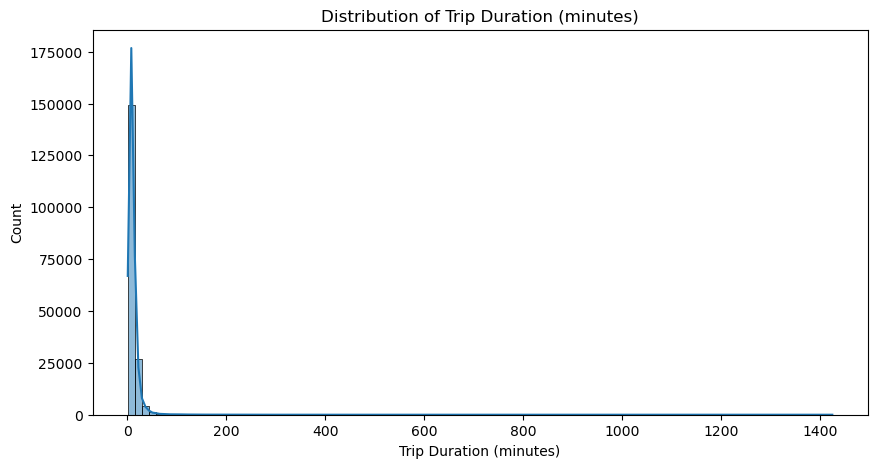

```python
# Question: What is the distribution of trip durations?
plt.figure(figsize=(10,5))
sns.histplot(df['duration_sec']/60, bins=100, kde=True)
plt.title('Distribution of Trip Duration (minutes)')
plt.xlabel('Trip Duration (minutes)')
plt.ylabel('Count')
plt.show()
```

```python
# Check for missing values
print('Missing values per column:')
print(df.isnull().sum())

# Handle missing values
# For birth year and gender, we'll keep the missing values but note them in our analysis
# Convert start_time and end_time to datetime
df['start_time'] = pd.to_datetime(df['start_time'])
df['end_time'] = pd.to_datetime(df['end_time'])

# Create new features
df['trip_day_of_week'] = df['start_time'].dt.day_name()
df['trip_hour'] = df['start_time'].dt.hour
df['trip_month'] = df['start_time'].dt.month
df['trip_duration_min'] = df['duration_sec'] / 60

# Calculate trip distance (straight-line distance between start and end stations)
from math import radians, cos, sin, asin, sqrt

def haversine(lon1, lat1, lon2, lat2):
    """
    Calculate the great circle distance between two points
    on the earth (specified in decimal degrees)
    """
    # convert decimal degrees to radians
    lon1, lat1, lon2, lat2 = map(radians, [lon1, lat1, lon2, lat2])
    # haversine formula
    dlon = lon2 - lon1
    dlat = lat2 - lat1
    a = sin(dlat/2)**2 + cos(lat1) * cos(lat2) * sin(dlon/2)**2
    c = 2 * asin(sqrt(a))
    r = 6371 # Radius of earth in kilometers
    return c * r

# Apply the haversine function to calculate distance
df['trip_distance_km'] = df.apply(lambda row: haversine(
    row['start_station_longitude'],
    row['start_station_latitude'],
    row['end_station_longitude'],
    row['end_station_latitude']), axis=1)

# Convert member_birth_year to age
df['member_birth_year'] = pd.to_numeric(df['member_birth_year'], errors='coerce')
current_year = 2019  # Data is from February 2019
df['member_age'] = current_year - df['member_birth_year']

# Remove outliers in trip duration (>3h or <1min might be errors or unusual cases)
df_filtered = df[(df['trip_duration_min'] <= 180) & (df['trip_duration_min'] >= 1)]

# Show the filtered dataset
print('\nOriginal dataset shape:', df.shape)
print('Filtered dataset shape:', df_filtered.shape)
df_filtered.head()
```

[output not shown]

|  | duration_sec | start_time | end_time | start_station_id | start_station_name | start_station_latitude | start_station_longitude | end_station_id | end_station_name | end_station_latitude | ... | user_type | member_birth_year | member_gender | bike_share_for_all_trip | trip_day_of_week | trip_hour | trip_month | trip_duration_min | trip_distance_km | member_age |
| --- | --- | --- | --- | --- | --- | --- | --- | --- | --- | --- | --- | --- | --- | --- | --- | --- | --- | --- | --- | --- | --- |
| 4 | 1585 | 2019-02-28 23:54:18.549 | 2019-03-01 00:20:44.074 | 7.0 | Frank H Ogawa Plaza | 37.804562 | -122.271738 | 222.0 | 10th Ave at E 15th St | 37.792714 | ... | Subscriber | 1974.0 | Male | Yes | Thursday | 23 | 2 | 26.416667 | 2.409301 | 45.0 |
| 5 | 1793 | 2019-02-28 23:49:58.632 | 2019-03-01 00:19:51.760 | 93.0 | 4th St at Mission Bay Blvd S | 37.770407 | -122.391198 | 323.0 | Broadway at Kearny | 37.798014 | ... | Subscriber | 1959.0 | Male | No | Thursday | 23 | 2 | 29.883333 | 3.332203 | 60.0 |
| 6 | 1147 | 2019-02-28 23:55:35.104 | 2019-03-01 00:14:42.588 | 300.0 | Palm St at Willow St | 37.317298 | -121.884995 | 312.0 | San Jose Diridon Station | 37.329732 | ... | Subscriber | 1983.0 | Female | No | Thursday | 23 | 2 | 19.116667 | 2.028551 | 36.0 |
| 7 | 1615 | 2019-02-28 23:41:06.766 | 2019-03-01 00:08:02.756 | 10.0 | Washington St at Kearny St | 37.795393 | -122.404770 | 127.0 | Valencia St at 21st St | 37.756708 | ... | Subscriber | 1989.0 | Male | No | Thursday | 23 | 2 | 26.916667 | 4.532568 | 30.0 |
| 8 | 1570 | 2019-02-28 23:41:48.790 | 2019-03-01 00:07:59.715 | 10.0 | Washington St at Kearny St | 37.795393 | -122.404770 | 127.0 | Valencia St at 21st St | 37.756708 | ... | Subscriber | 1988.0 | Other | No | Thursday | 23 | 2 | 26.166667 | 4.532568 | 31.0 |

5 rows × 22 columns

### Univariate Exploration: User Types

Let's look at the distribution of user types (Subscribers vs Customers).

Let's visualize the proportion of Subscribers vs. Customers using a pie chart.

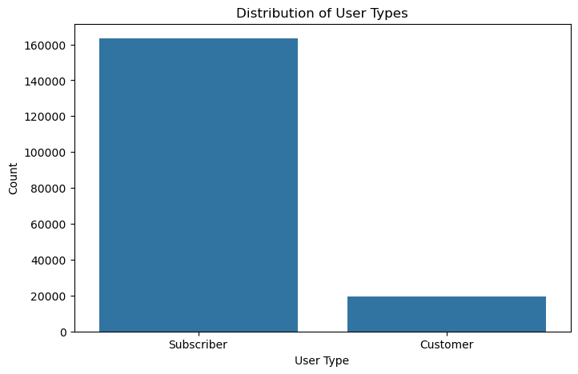

```
User Type Distribution:
user_type
Subscriber    89.270199
Customer      10.729801
Name: proportion, dtype: float64
```

```python
# Question: What is the distribution of user types?
plt.figure(figsize=(8, 5))
sns.countplot(data=df_filtered, x='user_type')
plt.title('Distribution of User Types')
plt.xlabel('User Type')
plt.ylabel('Count')
plt.show()

# Calculate percentages
user_type_counts = df_filtered['user_type'].value_counts(normalize=True) * 100
print(f"User Type Distribution:\n{user_type_counts}")

# Observations:
# The majority of users are Subscribers (regular users with membership),
# while Customers (casual or one-time users) make up a smaller portion of the user base.
```

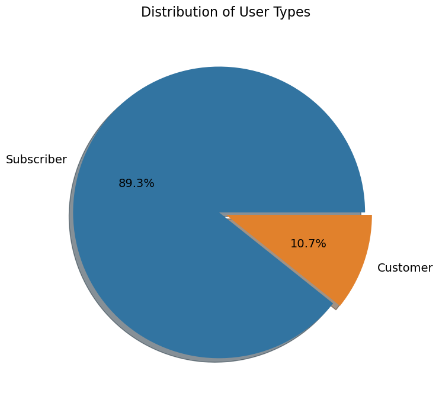

```python
# Question: What is the distribution of user types (pie chart)?
plt.figure(figsize=(10, 8))
user_counts = df_filtered['user_type'].value_counts()
plt.pie(user_counts, labels=user_counts.index, autopct='%1.1f%%',
        colors=['#3274A1', '#E1812C'], explode=(0.05, 0),
        textprops={'fontsize': 14}, shadow=True)
plt.title('Distribution of User Types', fontsize=16, pad=20)
plt.show()

# Observations:
# The pie chart clearly illustrates that Subscribers form the vast majority of users (89.3%),
# while Customers (casual or one-time users) make up only 10.7% of the user base.
```

### Univariate Exploration: Gender Distribution

Let's look at the distribution of users by gender.

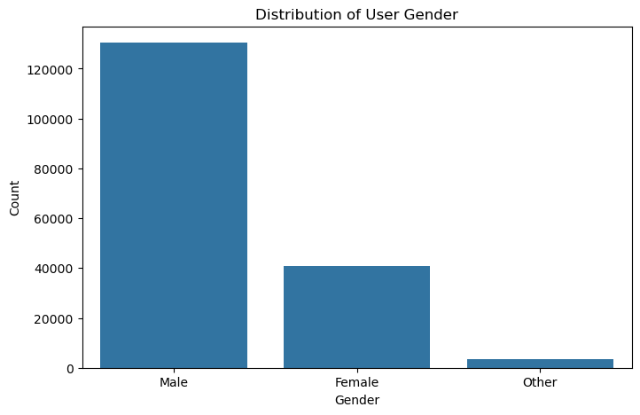

```
Gender Distribution:
member_gender
Male      74.622033
Female    23.303798
Other      2.074169
Name: proportion, dtype: float64
```

```python
# Question: What is the gender distribution of the users?
plt.figure(figsize=(8, 5))
sns.countplot(data=df_filtered, x='member_gender')
plt.title('Distribution of User Gender')
plt.xlabel('Gender')
plt.ylabel('Count')
plt.show()

# Calculate percentages
gender_counts = df_filtered['member_gender'].value_counts(normalize=True) * 100
print(f"Gender Distribution:\n{gender_counts}")

# Observations:
# Male users form the majority of the bike-sharing service users,
# followed by female users. 'Other' gender and missing values make up a small portion of the data.
```

### Univariate Exploration: Trip Timing

Let's explore when trips are most common during the day.

Let's explore how trip frequency varies by day of the week.

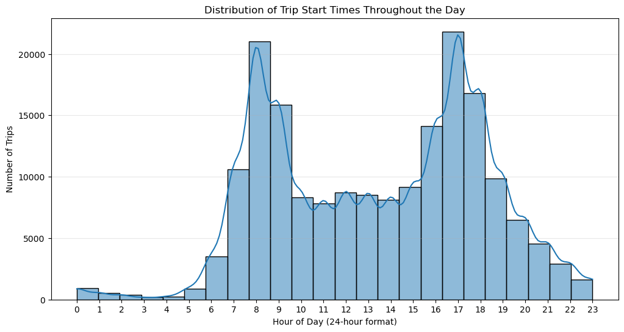

```python
# Question: How are trips distributed throughout the day?
plt.figure(figsize=(12, 6))
sns.histplot(data=df_filtered, x='trip_hour', bins=24, kde=True)
plt.title('Distribution of Trip Start Times Throughout the Day')
plt.xlabel('Hour of Day (24-hour format)')
plt.ylabel('Number of Trips')
plt.xticks(range(0, 24))
plt.grid(axis='y', alpha=0.3)
plt.show()

# Observations:
# There are clear peak hours corresponding to typical commute times:
# - Morning peak around 8-9 AM
# - Evening peak around 5-6 PM
# This suggests many users are using the bike-sharing service for commuting to and from work.
```

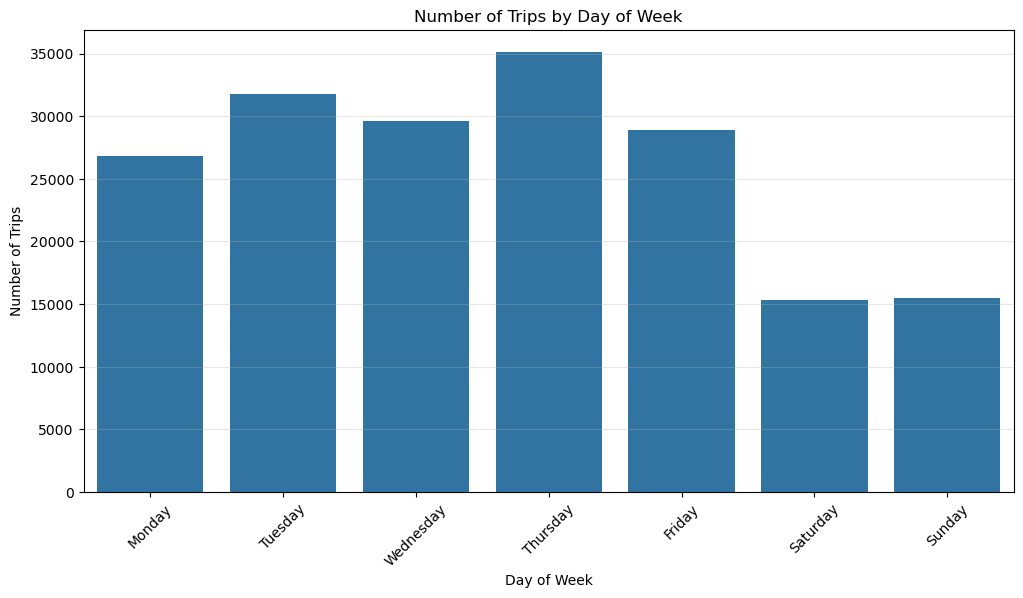

```
Trip Counts by Day of Week:
trip_day_of_week
Monday       26795
Tuesday      31758
Wednesday    29600
Thursday     35126
Friday       28927
Saturday     15339
Sunday       15450
Name: count, dtype: int64
```

```python
# Question: How do trip counts vary by day of the week?
# First, let's create a categorical type with the correct order of days
day_order = ['Monday', 'Tuesday', 'Wednesday', 'Thursday', 'Friday', 'Saturday', 'Sunday']
df_filtered['trip_day_of_week'] = pd.Categorical(df_filtered['trip_day_of_week'], categories=day_order, ordered=True)

plt.figure(figsize=(12, 6))
sns.countplot(data=df_filtered, x='trip_day_of_week', order=day_order)
plt.title('Number of Trips by Day of Week')
plt.xlabel('Day of Week')
plt.ylabel('Number of Trips')
plt.xticks(rotation=45)
plt.grid(axis='y', alpha=0.3)
plt.show()

# Calculate statistics
day_counts = df_filtered['trip_day_of_week'].value_counts().reindex(day_order)
print(f"Trip Counts by Day of Week:\n{day_counts}")

# Observations:
# There are more trips during weekdays compared to weekends.
# This further supports the hypothesis that many users are using
# the service for commuting to work or school during weekdays.
```

## Bivariate Exploration

Explore relationships between pairs of variables to uncover patterns and correlations.

### Trip Duration by User Type

Let's examine if there's a difference in trip duration between subscriber and customer users.

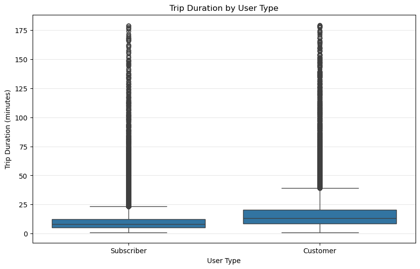

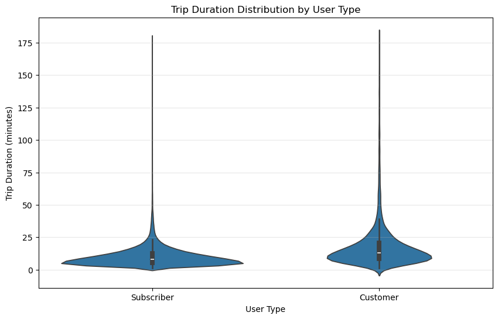

```
Trip Duration Statistics by User Type:
                 mean     median        std
user_type
Customer    18.521836  13.050000  20.017768
Subscriber  10.100444   8.166667   8.533081
```

```python
# Question: How does trip duration differ between user types?
plt.figure(figsize=(10, 6))
sns.boxplot(data=df_filtered, x='user_type', y='trip_duration_min')
plt.title('Trip Duration by User Type')
plt.xlabel('User Type')
plt.ylabel('Trip Duration (minutes)')
plt.grid(axis='y', alpha=0.3)
plt.show()

# Add a violin plot for more detailed distribution view
plt.figure(figsize=(10, 6))
sns.violinplot(data=df_filtered, x='user_type', y='trip_duration_min')
plt.title('Trip Duration Distribution by User Type')
plt.xlabel('User Type')
plt.ylabel('Trip Duration (minutes)')
plt.grid(axis='y', alpha=0.3)
plt.show()

# Calculate summary statistics
user_type_duration_stats = df_filtered.groupby('user_type')['trip_duration_min'].agg(['mean', 'median', 'std'])
print(f"Trip Duration Statistics by User Type:\n{user_type_duration_stats}")

# Observations:
# Customers tend to take significantly longer trips than Subscribers.
# This suggests different usage patterns:
# - Subscribers might be using the service for regular commuting (shorter, routine trips)
# - Customers might be using the service for leisure or tourism (longer, exploratory trips)
```